# NGS Gene Coverage Plots

## Call mosdepth on bam to calculate bp-specific read depth

mosdepth, by default, will generate base pair resolution coverage across the entire genome. Another fantastic tool from Brent Peterson and Aaron Quinlan (some point I’ll do a gushy post on [all](http://peddy.readthedocs.io/en/latest/) [of](http://gemini.readthedocs.io/en/latest/) [the](http://bedtools.readthedocs.io/en/latest/) useful tools [Quinlan and company have made](http://quinlanlab.org/#software)).

mosdepth will run *very* quickly (minutes instead of hours), compared to `bedtools genomecov`.

```r
# bash
sinteractive --cpus-per-task 16
module load mosdepth
mosdepth -t 16 41001412010527 41001412010527_realigned_recal.bam &
```

## Intersect base pair depth info with transcript and exon number

The intersect is to select regions overlapping exons and to label them with the transcript name and exon number present in gencode_genes_v27lift37.codingExons.ensembl.bed.gz

```r
# bash

# gencode_genes_v27lift37.codingExons.bed was downloaded from the UCSC table browser from genocde gene v27lift37 and 'coding exons' with 0 padding were selected as the output for the bed file
# my ~/git/ChromosomeMappings/convert_notation.py was then used to convert the UCSC notation in ensembl notation, which my bam uses
# files in biowulf2:/data/mcgaugheyd/genomes/GRCh37/
module load bedtools
~/git/ChromosomeMappings/convert_notation.py -c ~/git/ChromosomeMappings/GRCh37_gencode2ensembl.txt -f gencode_genes_v27lift37.codingExons.bed | sort -k1,1 -k2,2n | gzip > gencode_genes_v27lift37.codingExons.ensembl.bed.gz
bedtools intersect -wa -wb -a 41001412010527.per-base.bed.gz -b /data/mcgaugheyd/genomes/GRCh37/gencode_genes_v27lift37.codingExons.ensembl.bed.gz | bgzip  > 41001412010527.per-base.labeled.bed.gz &
```

# Now it’s R time!

## Prepare Metadata

You’ll need HGNC <-> Ensembl Transcript converter and the Gencode GTF

The first file is used to match gene ‘names’ with ensembl transcript ID

The second file is used to semi-accurately pick the ‘canonical’ transcript for a gene (pick the appris transcript, then the longest)

```r
library(data.table)
library(tidyverse)
library(cowplot)
library(stringr)
metadata <- fread('gzcat ~/GenomicData/gencode.v27lift37.metadata.HGNC.gz', header=F)
colnames(metadata) <- c('Transcript','Name')
gencode <- fread('gzcat ~/GenomicData/gencode.v27lift37.basic.annotation.gtf.gz', header=F, skip=4)
```

```
Read 1.8% of 1651703 rows
Read 15.1% of 1651703 rows
Read 28.5% of 1651703 rows
Read 44.2% of 1651703 rows
Read 47.2% of 1651703 rows
Read 60.5% of 1651703 rows
Read 76.3% of 1651703 rows
Read 95.1% of 1651703 rows
Read 1651703 rows and 9 (of 9) columns from 0.822 GB file in 00:00:11
```

```r
gencode2 <- gencode %>% filter(V3=='transcript') %>%
  filter(grepl('appris_principal', V9)) %>%
  rowwise() %>%
  mutate(Transcript = str_extract(V9,'ENST\\d{11}\\.\\d+'), # use regex to graph ensembl transcript
         Gene = str_extract(V9, 'gene_name\\s\\".*?;'), # and the gene name
         Size=V5-V4) %>%
  separate(Gene, c('skip','Name','skip2'),'\"') %>% # now you have to remove the 'gene name' part
  select(-skip, -skip2) %>%
  group_by(Name) %>% top_n(1)
```

```
Grouping rowwise data frame strips rowwise natureSelecting by Size
```

## Load mosdepth / bedtools intersect data and prep

Label coverage chunks with the depth of their coverage with case_when and extract the transcript name and exon number with a bunch of `separate` commands

```r
depth_data <- fread('gzcat ~/Desktop/41001412010527.per-base.labeled.bed.gz')
```

[output not shown]

```r
dd_processed <- depth_data %>%
  separate(V8, c('Transcript','Rest'), '_cds_') %>%
  separate(Rest, c('Before','Stuff'),'_chr') %>%
  separate(Before, c('Exon Number','Num2'),sep='_') %>%
  mutate(Depth = case_when(V4 < 10 ~ '< 10 Reads',
                           V4 < 20 ~ '< 20 Reads',
                           TRUE ~ '>= 20 Reads')) %>%
  mutate(Depth=factor(Depth, levels=c('< 10 Reads','< 20 Reads','>= 20 Reads'))) %>%
  mutate(Transcript=case_when(grepl('_',Transcript) ~ gsub('_.','',Transcript),
                              TRUE ~ Transcript)) %>%
  select(Chr=V1, Start=V2, End=V3, Read_Depth=V4, Transcript, Strand=V10, Depth, `Exon Number`, ExonStart=V6, ExonEnd=V7)
dd_processed <- left_join(dd_processed, metadata, by=c('Transcript'))
```

## Plot Maker, version 1

Faceted by exon. One plot per gene and using cowplot to *glue* them together

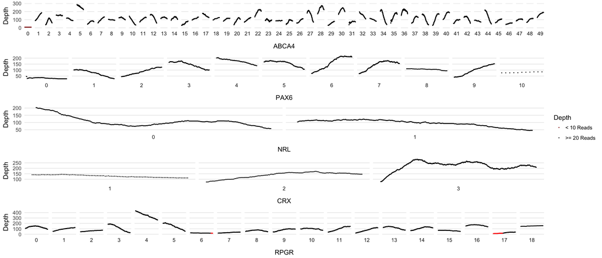

```r
genes <- c('PAX6','ABCA4','NRL','CRX','RPGR')
transcripts = gencode2 %>% filter(Name %in% genes) %>% pull(Transcript)
scale_colour_custom <- function(...){
    ggplot2:::manual_scale('colour',
                           values = setNames(c('darkred', 'red', 'black'),
                                             c('< 10 Reads','< 20 Reads','>= 20 Reads')),
                           ...)
}
plot_maker <- function(tx){
  num_of_exons <- dd_processed %>% filter(Transcript==tx) %>% pull(`Exon Number`) %>% as.numeric() %>% max()
  gene_name <-  dd_processed %>% filter(Transcript==tx) %>% pull(Name) %>% unique()
  # expand to create a row for each sequence and fill in previous values
  dd_processed %>% filter(Transcript==tx) %>% group_by(`Exon Number`) %>%
    expand(Start=full_seq(c(Start,End),1)) %>%
    left_join(.,  dd_processed %>% filter(Transcript==tx)) %>% # create one row per base position, grouped by Exon Number https://stackoverflow.com/questions/42866119/fill-missing-values-in-data-frame-using-dplyr-complete-within-groups
    fill(Chr:Name) %>% # fill missing values https://stackoverflow.com/questions/40040834/r-replace-na-with-previous-or-next-value-by-group-using-dplyr
    ungroup() %>%
    mutate(`Exon Number`= factor(`Exon Number`,levels=0:num_of_exons)) %>%
    mutate(Depth = factor(Depth, levels=c('< 10 Reads','< 20 Reads','>= 20 Reads'))) %>%
    ggplot(aes(x=Start, xend=End, y=Read_Depth, yend=Read_Depth, colour=Depth)) +
    facet_wrap(~`Exon Number`, scales = 'free_x', nrow=1, strip.position = 'bottom') +
    geom_point(size=0.1) + theme_minimal()+ scale_colour_custom() +
    theme(axis.text.x=element_blank(),
          axis.ticks.x = element_blank(),
          panel.grid.minor = element_blank(),
          panel.grid.major.x = element_blank(),
          legend.position = 'none') +
    ylab('Depth') +
    xlab(paste0(gene_name[1]))
}
plots <- list()
for (i in transcripts){
  plots[[i]] <- plot_maker(i)
}
legend <- get_legend(plots[[names(plots)[1]]] + theme(legend.position='right'))
plot_grid(plot_grid(plotlist = plots, ncol=1, hjust=-2), legend, ncol=2, rel_widths = c(5,0.5))
```

## Version 2

A bit tighter. Recalculates coordinates to glue all of the exons together in one plot. I can facet by gene. A bit harder to read, but is more accurate as the exons and gene lengths are proportional

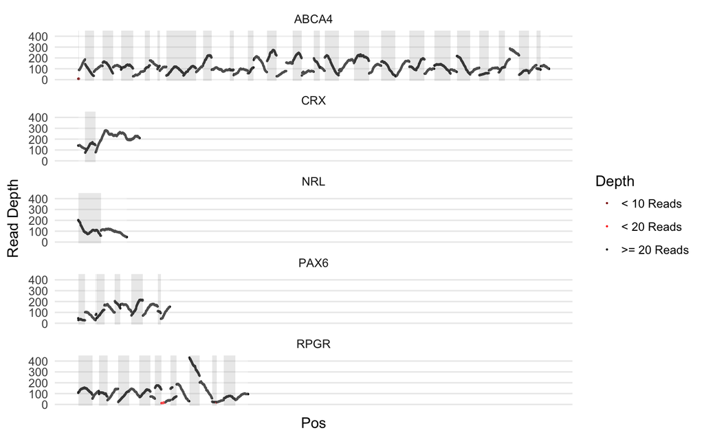

```r
genes <- c('PAX6','ABCA4','NRL','CRX','RPGR')
tx = gencode2 %>% filter(Name %in% genes) %>% pull(Transcript)
dd_expanded <- dd_processed %>% filter(Transcript %in% tx) %>% group_by(Transcript, `Exon Number`) %>%
    expand(Start=full_seq(c(Start,End),1)) %>%
    left_join(.,  dd_processed %>% filter(Transcript %in% tx)) %>% # create one row per base position, grouped by Exon Number https://stackoverflow.com/questions/42866119/fill-missing-values-in-data-frame-using-dplyr-complete-within-groups
    fill(Chr:Name) # fill missing values https://stackoverflow.com/questions/40040834/r-replace-na-with-previous-or-next-value-by-group-using-dplyr
dd_expanded <- dd_expanded %>% group_by(Name) %>% mutate(Pos = 1:n())
even_odds_marking <- dd_expanded %>% group_by(Name, `Exon Number`) %>% summarise(Start=min(Pos), End=max(Pos)) %>% mutate(Exon = case_when(as.numeric(`Exon Number`) %% 2 == 0 ~ 'even', TRUE ~ 'odd'))
plot_data<-bind_rows(dd_expanded,even_odds_marking)
ggplot() +
    geom_point(data =  plot_data %>% filter(is.na(Exon)), aes(x=Pos, y=Read_Depth, colour=Depth),size=0.1)  +
    facet_wrap(~Name, ncol=1) +
    geom_rect(data = plot_data %>% filter(!is.na(Exon)), aes(xmin=Start, xmax=End, ymin=-Inf, ymax=Inf, fill=Exon)) +
    scale_fill_manual(values = alpha(c("gray", "white"), .3)) +
    scale_colour_custom() +
    theme_minimal() +
    theme(axis.text.x=element_blank(),
          axis.ticks.x = element_blank(),
          panel.grid.minor = element_blank(),
          panel.grid.major.x = element_blank())+
    guides(fill=FALSE) +
    ylab('Read Depth')
```